# Módulo 5

Author

Adrián Tobar Nicolau

# Guía para ggplot2

El paquete ggplot2 permite la creación de figuras dando un control total sobre sus propiedades. En esta sesión vamos a entrar en como crear, colorear, escalar y guardar una figura de ggplot2 a nuestro gusto.

## Antes de empezar

Cargamos los paquetes que usaremos.

```r
library(tidyverse)
library(MASS)
```

Preparamos los datos de ejemplo.

```r
data("birthwt")
bwt <- birthwt |>
  mutate(
    smoke = factor(smoke, labels = c("No fumadora",
                                     "Fumadora")),
    ht    = factor(ht, labels = c("No HTA",
                                  "HTA")),
    ui    = factor(ui, labels = c("No irritabilidad",
                                  "Irritabilidad")),
    race  = factor(race, labels = c("Blanca",
                                    "Negra",
                                    "Otra"))
  )
#fijamos peso a kg
bwt$lwt= 0.45359237*bwt$lwt
```

## Datos, estética, y geometría

Toda figura de `ggplot2` tiene datos, estética y geometría.

Veamos un ejemplo básico.

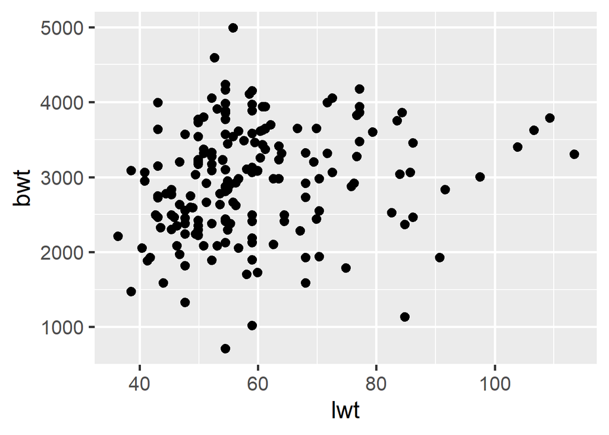

```r
ggplot(bwt, aes(x = lwt, y = bwt)) + geom_point()
```

Este gráfico de puntos está definido por

1. Datos: bwt.
2. Aes (estética): en el eje $x$ el peso de la madre en su último período menstrual y en el eje $y$ el peso del neonato en gramos.
3. Geometría: gráfico de puntos.

Habitualmente tendremos dos datos, uno para el eje $x$ y otro para el eje $y$. Por comodidad podemos obviar la notación $x=,y=$ de la siguiente manera

```r
ggplot(bwt, aes(lwt,bwt)) + geom_point()
```

### Color

El paquete `ggplot2` permite colorear la figura en función de datos

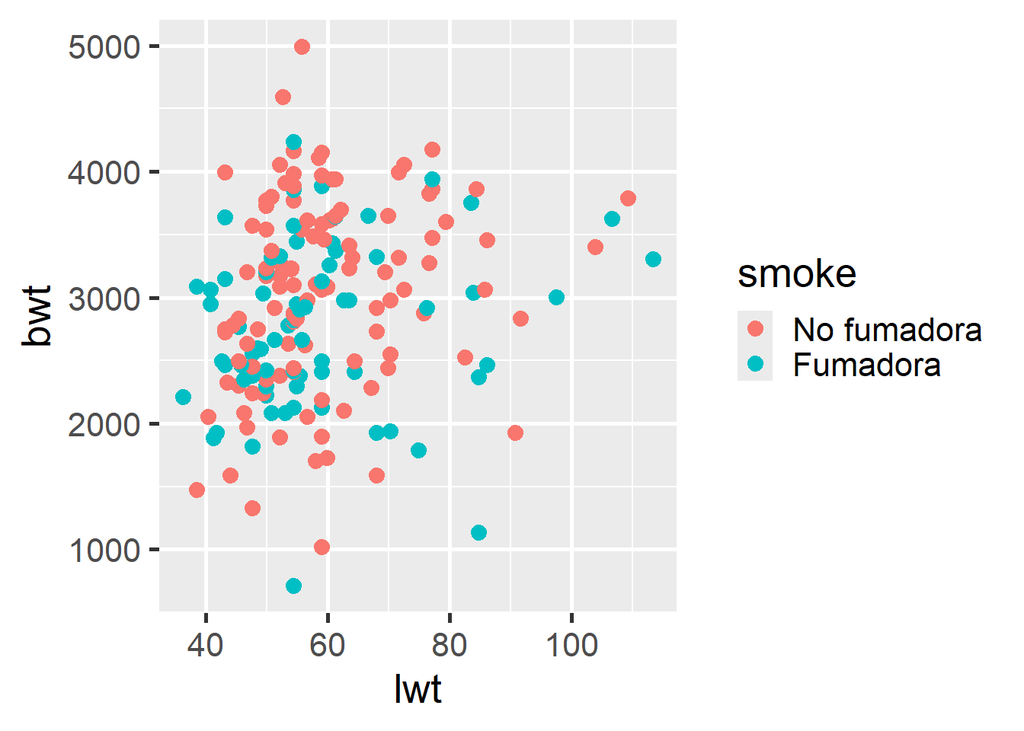

```r
ggplot(bwt, aes(lwt,bwt, color=smoke)) + geom_point()
```

Además, detecta si usar un gradiente o categorías.

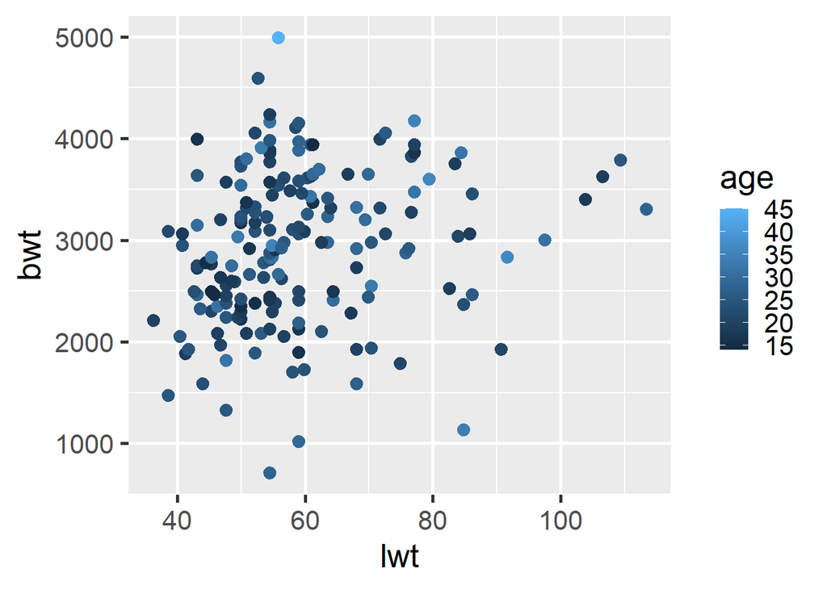

```r
ggplot(bwt, aes(lwt,bwt, color=age)) + geom_point()
```

### Las paletas básicas de `ggplot2`

### Ejemplo categórico por defecto

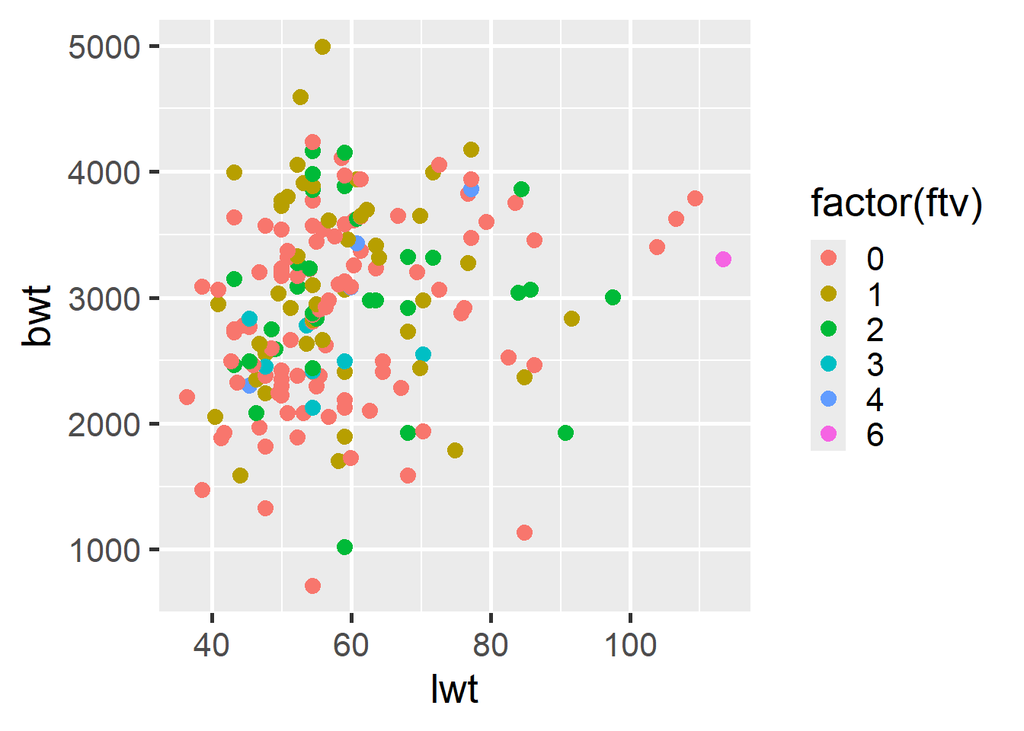

```r
ggplot(bwt, aes(lwt,bwt, color=factor(ftv))) +
  geom_point() + scale_colour_hue()
```

**OJO:** para que `ggplot2` entienda una categoría como discreta tiene que estar como factor ypara que sea continua no.

### Ejemplo grises por defecto

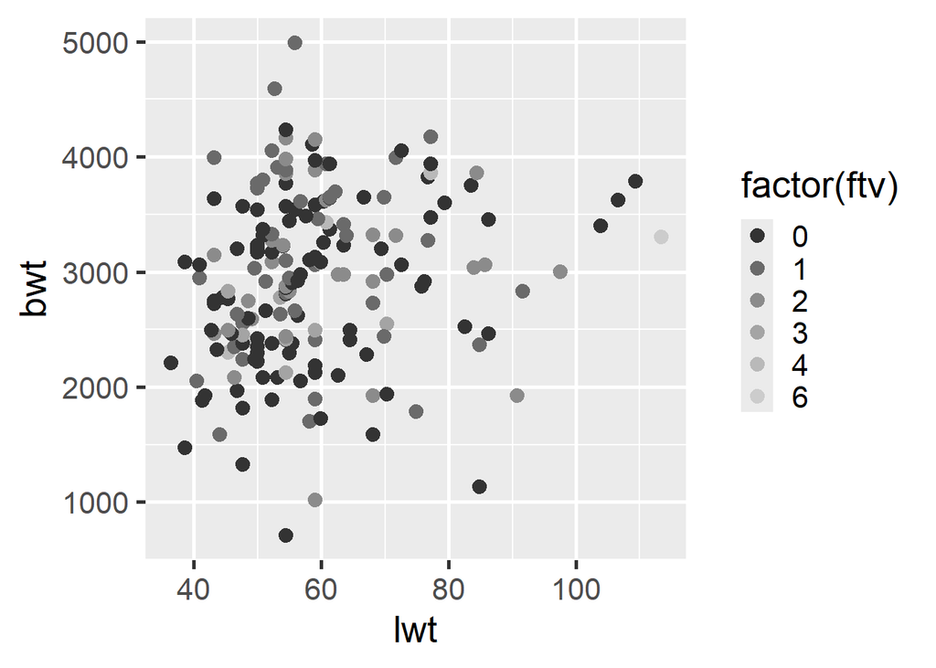

```r
ggplot(bwt, aes(lwt,bwt, color=factor(ftv))) +
  geom_point() + scale_colour_grey()
```